# MVA_HW_1

aa2569@scarletmail.rutgers.edu

2/5/2023

## Loading the Sparrows file

```r
library(readr)
library(MVA)
library(HSAUR2)
Bumpus_sparrows <- read_csv("/Users/ajayvishnu/Desktop/Bumpus_sparrows.csv")
sparr <- Bumpus_sparrows
sparr
```

```
## # A tibble: 49 × 6
##    Survivorship Total_length Alar_extent L_beak_head L_humerous L_keel_sternum
##    <chr>               <dbl>       <dbl>       <dbl>      <dbl>          <dbl>
##  1 S                     156         245        31.6       18.5           20.5
##  2 S                     154         240        30.4       17.9           19.6
##  3 S                     153         240        31         18.4           20.6
##  4 S                     153         236        30.9       17.7           20.2
##  5 S                     155         243        31.5       18.6           20.3
##  6 S                     163         247        32         19             20.9
##  7 S                     157         238        30.9       18.4           20.2
##  8 S                     155         239        32.8       18.6           21.2
##  9 S                     164         248        32.7       19.1           21.1
## 10 S                     158         238        31         18.8           22
## # … with 39 more rows
```

- We can see that the first column shows the Survivorship of the sparrows.
- NS - Not Survived, S - Survived.
- All the other 5 columns are numeric values.
- Later let us divide the data into two subsets (Survived & Not survived and perform the analysis on them separately)

## Separating into two different matrices

```r
ns_sparr <- subset(sparr, Survivorship == "NS")
s_sparr <- subset(sparr, Survivorship == "S")
ns_sparr
```

```
## # A tibble: 28 × 6
##    Survivorship Total_length Alar_extent L_beak_head L_humerous L_keel_sternum
##    <chr>               <dbl>       <dbl>       <dbl>      <dbl>          <dbl>
##  1 NS                    155         240        31.4       18             20.7
##  2 NS                    156         240        31.5       18.2           20.6
##  3 NS                    160         242        32.6       18.8           21.7
##  4 NS                    152         232        30.3       17.2           19.8
##  5 NS                    160         250        31.7       18.8           22.5
##  6 NS                    155         237        31         18.5           20
##  7 NS                    157         245        32.2       19.5           21.4
##  8 NS                    165         245        33.1       19.8           22.7
##  9 NS                    153         231        30.1       17.3           19.8
## 10 NS                    162         239        30.3       18             23.1
## # … with 18 more rows
```

```r
s_sparr
```

```
## # A tibble: 21 × 6
##    Survivorship Total_length Alar_extent L_beak_head L_humerous L_keel_sternum
##    <chr>               <dbl>       <dbl>       <dbl>      <dbl>          <dbl>
##  1 S                     156         245        31.6       18.5           20.5
##  2 S                     154         240        30.4       17.9           19.6
##  3 S                     153         240        31         18.4           20.6
##  4 S                     153         236        30.9       17.7           20.2
##  5 S                     155         243        31.5       18.6           20.3
##  6 S                     163         247        32         19             20.9
##  7 S                     157         238        30.9       18.4           20.2
##  8 S                     155         239        32.8       18.6           21.2
##  9 S                     164         248        32.7       19.1           21.1
## 10 S                     158         238        31         18.8           22
## # … with 11 more rows
```

- The survived and not survived data has been seperated now.
- However, to perform the analysis, we need only the numeric data to be available.

## Droping the first column

```r
ns_sp <- ns_sparr[,-1]
s_sp <- s_sparr[,-1]
ns_sp
```

```
## # A tibble: 28 × 5
##    Total_length Alar_extent L_beak_head L_humerous L_keel_sternum
##           <dbl>       <dbl>       <dbl>      <dbl>          <dbl>
##  1          155         240        31.4       18             20.7
##  2          156         240        31.5       18.2           20.6
##  3          160         242        32.6       18.8           21.7
##  4          152         232        30.3       17.2           19.8
##  5          160         250        31.7       18.8           22.5
##  6          155         237        31         18.5           20
##  7          157         245        32.2       19.5           21.4
##  8          165         245        33.1       19.8           22.7
##  9          153         231        30.1       17.3           19.8
## 10          162         239        30.3       18             23.1
## # … with 18 more rows
```

```r
s_sp
```

```
## # A tibble: 21 × 5
##    Total_length Alar_extent L_beak_head L_humerous L_keel_sternum
##           <dbl>       <dbl>       <dbl>      <dbl>          <dbl>
##  1          156         245        31.6       18.5           20.5
##  2          154         240        30.4       17.9           19.6
##  3          153         240        31         18.4           20.6
##  4          153         236        30.9       17.7           20.2
##  5          155         243        31.5       18.6           20.3
##  6          163         247        32         19             20.9
##  7          157         238        30.9       18.4           20.2
##  8          155         239        32.8       18.6           21.2
##  9          164         248        32.7       19.1           21.1
## 10          158         238        31         18.8           22
## # … with 11 more rows
```

- Further, we can calculate the column means, correlation, and covaraiance for the two datasets spearately and identify patterns.

## Column Means

```r
colMeans(ns_sp)
```

```
##   Total_length    Alar_extent    L_beak_head     L_humerous L_keel_sternum
##      158.42857      241.57143       31.47857       18.44643       20.83929
```

```r
colMeans(s_sp)
```

```
##   Total_length    Alar_extent    L_beak_head     L_humerous L_keel_sternum
##      157.38095      241.00000       31.43333       18.50000       20.80952
```

- Except for L_humerous, rest all column means are larger for not survived sparrows.
- Further, we can deep dive and see the covariance and correlation matrices.

## Covariance Matrix

```r
cov(ns_sp)
```

```
##                Total_length Alar_extent L_beak_head L_humerous L_keel_sternum
## Total_length      15.068783   17.190476   2.2428571  1.7460317      2.9306878
## Alar_extent       17.190476   32.550265   3.3978836  2.9502646      4.0656085
## L_beak_head        2.242857    3.397884   0.7284127  0.4695503      0.5590212
## L_humerous         1.746032    2.950265   0.4695503  0.4344312      0.5058862
## L_keel_sternum     2.930688    4.065608   0.5590212  0.5058862      1.3209921
```

```r
cov(s_sp)
```

```
##                Total_length Alar_extent L_beak_head L_humerous L_keel_sternum
## Total_length      11.047619        9.10   1.5566667     0.8700      1.2861905
## Alar_extent        9.100000       17.50   1.9100000     1.3100      0.8800000
## L_beak_head        1.556667        1.91   0.5313333     0.1890      0.2396667
## L_humerous         0.870000        1.31   0.1890000     0.1760      0.1325000
## L_keel_sternum     1.286190        0.88   0.2396667     0.1325      0.5749048
```

## Correlation Matrix

```r
cor(ns_sp)
```

```
##                Total_length Alar_extent L_beak_head L_humerous L_keel_sternum
## Total_length      1.0000000   0.7761963   0.6769768  0.6824212      0.6568714
## Alar_extent       0.7761963   1.0000000   0.6978185  0.7845546      0.6200093
## L_beak_head       0.6769768   0.6978185   1.0000000  0.8347046      0.5698878
## L_humerous        0.6824212   0.7845546   0.8347046  1.0000000      0.6677936
## L_keel_sternum    0.6568714   0.6200093   0.5698878  0.6677936      1.0000000
```

```r
cor(s_sp)
```

```
##                Total_length Alar_extent L_beak_head L_humerous L_keel_sternum
## Total_length      1.0000000   0.6544674   0.6425068  0.6239195      0.5103557
## Alar_extent       0.6544674   1.0000000   0.6263698  0.7464418      0.2774378
## L_beak_head       0.6425068   0.6263698   1.0000000  0.6180476      0.4336368
## L_humerous        0.6239195   0.7464418   0.6180476  1.0000000      0.4165447
## L_keel_sternum    0.5103557   0.2774378   0.4336368  0.4165447      1.0000000
```

- Compared to covariance, correlation gives us better understanding between the two variables.
- For not survived sparrows, we can see that the correlation is highest for the L_humerous and the L_beak_head and least for the L_keel_sternum and the L_beak_head.
- For survived sparrows, we can see that the correlation is highest for the L_humerous and the Alar_extent and least for the L_keel_sternum and the Alar_extent.
- We can see that these are different to that compared to our covaraince results.

## Distance Matrix

```r
dist_ns = dist(scale(ns_sp[, c("Total_length","Alar_extent","L_beak_head","L_humerous","L_keel_sternum")],center = FALSE))
dist_s = dist(scale(s_sp[, c("Total_length","Alar_extent","L_beak_head","L_humerous","L_keel_sternum")],center = FALSE))
dist_ns
```

```
##             1          2          3          4          5          6          7
## 2  0.01354533
## 3  0.08032245 0.07453112
## 4  0.07863809 0.08555090 0.15649697
## 5  0.10809064 0.10637693 0.05711025 0.18193339
## 6  0.04578933 0.03849549 0.10254419 0.07814644 0.13534913
## 7  0.09296264 0.08442789 0.04728574 0.16703892 0.07118518 0.09889701
## 8  0.15839556 0.15172927 0.07997497 0.23378795 0.07872571 0.17351703 0.08509613
## 9  0.07946662 0.08543325 0.15594328 0.01105048 0.18122065 0.07549926 0.16585122
## 10 0.12580521 0.12941993 0.10769069 0.17484346 0.08164797 0.15622945 0.13353539
## 11 0.06839165 0.06036885 0.03868828 0.14038725 0.06450301 0.08259751 0.05277384
## 12 0.06406526 0.06147829 0.03262110 0.14012925 0.04618076 0.09323086 0.05778257
## 13 0.08996285 0.08485816 0.14418133 0.09826971 0.17122266 0.07030211 0.14199654
## 14 0.04354733 0.04332074 0.06630061 0.11161868 0.07638283 0.06592303 0.06867038
## 15 0.11361718 0.10897872 0.05558614 0.18948669 0.02669333 0.13460854 0.06104470
## 16 0.11882737 0.12079295 0.19283840 0.05737751 0.22527631 0.09959919 0.19718779
## 17 0.03510349 0.03017062 0.08600099 0.08769984 0.10843337 0.04329361 0.09372775
## 18 0.06687755 0.06471700 0.13481516 0.06056546 0.16895168 0.04646710 0.13763941
## 19 0.15432690 0.14909249 0.07643918 0.23165145 0.06898270 0.17499891 0.08594287
## 20 0.05203180 0.04733948 0.08022397 0.10421066 0.10217205 0.06639223 0.09779383
## 21 0.02723969 0.01966697 0.08469467 0.07948020 0.12304412 0.03112697 0.09381216
## 22 0.03869390 0.02690905 0.07919288 0.09222547 0.11672127 0.03318924 0.08685035
## 23 0.07562113 0.06406278 0.04978133 0.14657268 0.08520517 0.07779308 0.04328912
## 24 0.06183037 0.06320753 0.13589700 0.03802564 0.16641021 0.04815875 0.14260711
## 25 0.08098021 0.06876241 0.07098786 0.14511970 0.10178104 0.07545713 0.06148413
## 26 0.04629024 0.04270021 0.10019425 0.08296618 0.12540283 0.02630044 0.09309860
## 27 0.06732596 0.05979810 0.03692835 0.14093357 0.07604545 0.08834746 0.06385196
## 28 0.08279340 0.07317707 0.05208964 0.15352980 0.08184251 0.09380774 0.06308844
##             8          9         10         11         12         13         14
## 2
## 3
## 4
## 5
## 6
## 7
## 8
## 9  0.23200723
## 10 0.13449474 0.17234492
## 11 0.09884017 0.13793495 0.10436637
## 12 0.10011503 0.13963429 0.09041608 0.03254983
```

[output cut: 57 more lines]

```
## 14
## 15
## 16
## 17
## 18
## 19
## 20
## 21
## 22
## 23 0.05703760
## 24 0.06210533 0.11694202
## 25 0.05699046 0.02230665 0.11235842
## 26 0.04818523 0.08224454 0.06276079 0.08433645
## 27 0.05977030 0.03757906 0.11608835 0.05019881 0.09375896
## 28 0.06696019 0.02846004 0.12472757 0.03367366 0.10060490 0.02616127
```

```r
dist_s
```

```
##             1          2          3          4          5          6          7
## 2  0.06878467
## 3  0.03394604 0.05724620
## 4  0.06421479 0.03799440 0.04456705
## 5  0.01514313 0.06156984 0.02917302 0.05982191
## 6  0.05612299 0.11601861 0.08251712 0.11300207 0.06479748
## 7  0.03923325 0.04624305 0.03227388 0.04520379 0.03230481 0.07716708
## 8  0.05585684 0.11220518 0.06475769 0.09071149 0.06057743 0.06905236 0.07717382
## 9  0.07459959 0.13760930 0.10196049 0.13176944 0.08373430 0.02534894 0.09892442
## 10 0.08059980 0.12622307 0.07600430 0.10732316 0.08634705 0.07759599 0.08723445
## 11 0.07496849 0.12413780 0.07391906 0.10366748 0.08294553 0.07306843 0.08652265
## 12 0.03000016 0.07252617 0.04783754 0.07363112 0.03491794 0.04550013 0.03582636
## 13 0.08331581 0.14843842 0.10046888 0.13686021 0.09193918 0.04781579 0.10690355
## 14 0.04174920 0.08705526 0.06435669 0.09299342 0.03678564 0.05706330 0.05847804
## 15 0.05664504 0.04604955 0.05405297 0.04212636 0.04947063 0.09431725 0.03310779
## 16 0.04800417 0.04057386 0.03384941 0.02519107 0.04445989 0.09088663 0.02284311
## 17 0.05353944 0.10783345 0.06001365 0.09130232 0.06412403 0.05680546 0.07212795
## 18 0.05400591 0.06384435 0.02480651 0.04462457 0.05256164 0.09549337 0.04423406
## 19 0.05784326 0.04313664 0.03827579 0.04798529 0.04802310 0.09658511 0.02481759
## 20 0.08374401 0.14468744 0.10210114 0.12864644 0.09588468 0.05384042 0.10657543
## 21 0.06764042 0.10171608 0.06411696 0.07545151 0.07471605 0.08007136 0.06872619
##             8          9         10         11         12         13         14
## 2
## 3
## 4
## 5
## 6
## 7
## 8
## 9  0.07188844
## 10 0.07071605 0.08852493
## 11 0.06273547 0.08243528 0.01623364
## 12 0.07232714 0.06949556 0.07620343 0.07346262
## 13 0.06768567 0.04187100 0.06169598 0.05788067 0.08103272
## 14 0.07224124 0.07183801 0.10412268 0.10198915 0.04885825 0.08914074
## 15 0.08393278 0.11195736 0.11144907 0.10868920 0.05999588 0.12651608 0.06891539
## 16 0.07976441 0.11106738 0.09114715 0.08834410 0.05045670 0.11755685 0.07626533
## 17 0.05498414 0.06945858 0.03668855 0.02551817 0.05409309 0.05531508 0.08382159
## 18 0.07687151 0.11529732 0.06971946 0.06889000 0.06013915 0.10851261 0.08728076
## 19 0.09409790 0.11925086 0.09520164 0.09761605 0.05482551 0.12249313 0.07272573
```

[output cut: 8 more lines]

```
## 7
## 8
## 9
## 10
## 11
## 12
## 13
## 14
## 15
## 16 0.03205896
## 17 0.09453921 0.07486862
## 18 0.06641918 0.03766236 0.06048124
## 19 0.04690557 0.03442164 0.08661964 0.04374868
## 20 0.12129556 0.11091358 0.04916963 0.10671339 0.12612110
## 21 0.08090688 0.06222648 0.04259702 0.05757276 0.08368268 0.06760443
```

## Not Survived Plots

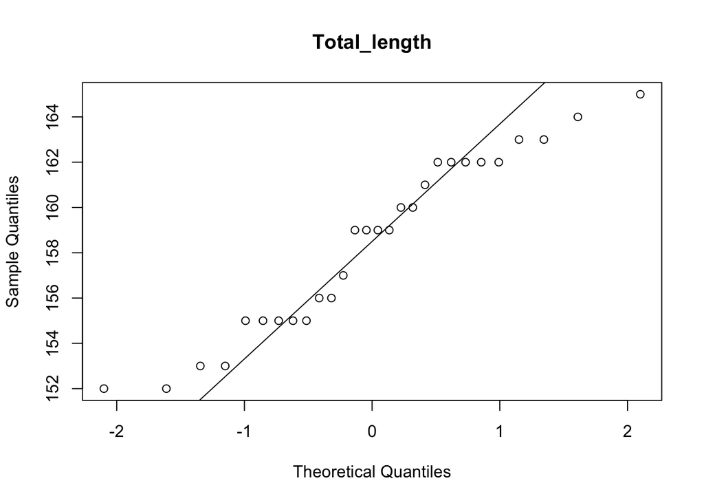

```r
ns_sp <- as.data.frame(ns_sp)
cm_ns_sp <- colMeans(ns_sp)
cov_ns_sp <- cov(ns_sp)
d_ns <- apply(ns_sp, MARGIN = 1, function(ns_sp)t(ns_sp - cm_ns_sp) %*% solve(cov_ns_sp) %*% (ns_sp - cm_ns_sp))
qqnorm(ns_sp[,"Total_length"], main = "Total_length"); qqline(ns_sp[,"Total_length"])
```

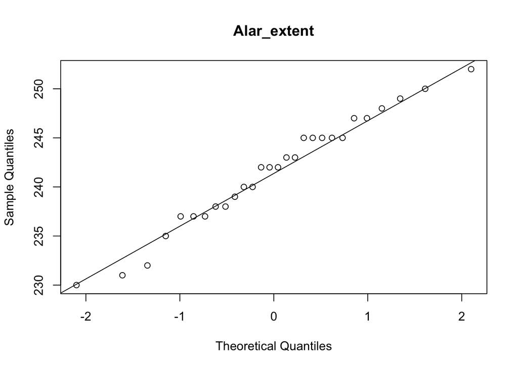

```r
qqnorm(ns_sp[,"Alar_extent"], main = "Alar_extent"); qqline(ns_sp[,"Alar_extent"])
```

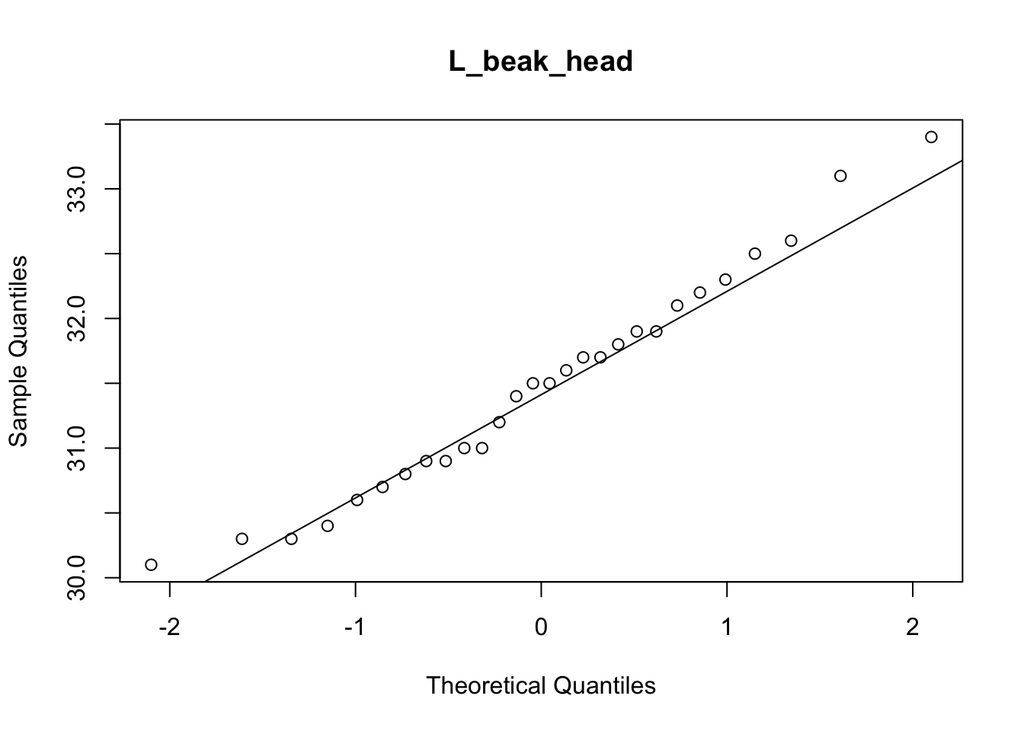

```r
qqnorm(ns_sp[,"L_beak_head"], main = "L_beak_head"); qqline(ns_sp[,"L_beak_head"])
```

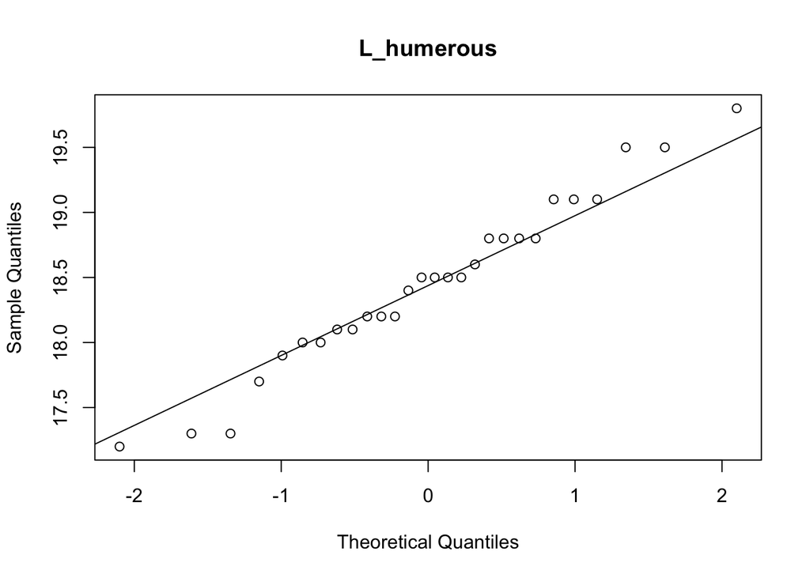

```r
qqnorm(ns_sp[,"L_humerous"], main = "L_humerous"); qqline(ns_sp[,"L_humerous"])
```

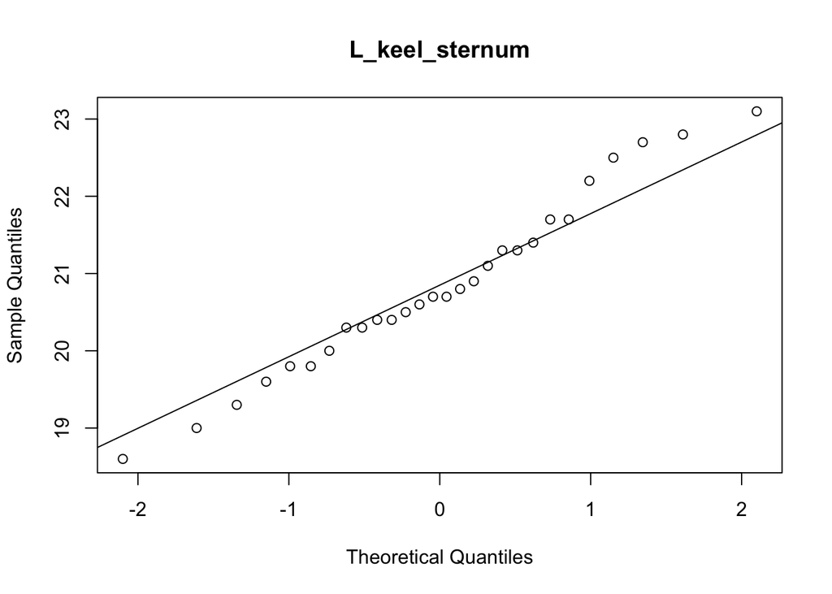

```r
qqnorm(ns_sp[,"L_keel_sternum"], main = "L_keel_sternum"); qqline(ns_sp[,"L_keel_sternum"])
```

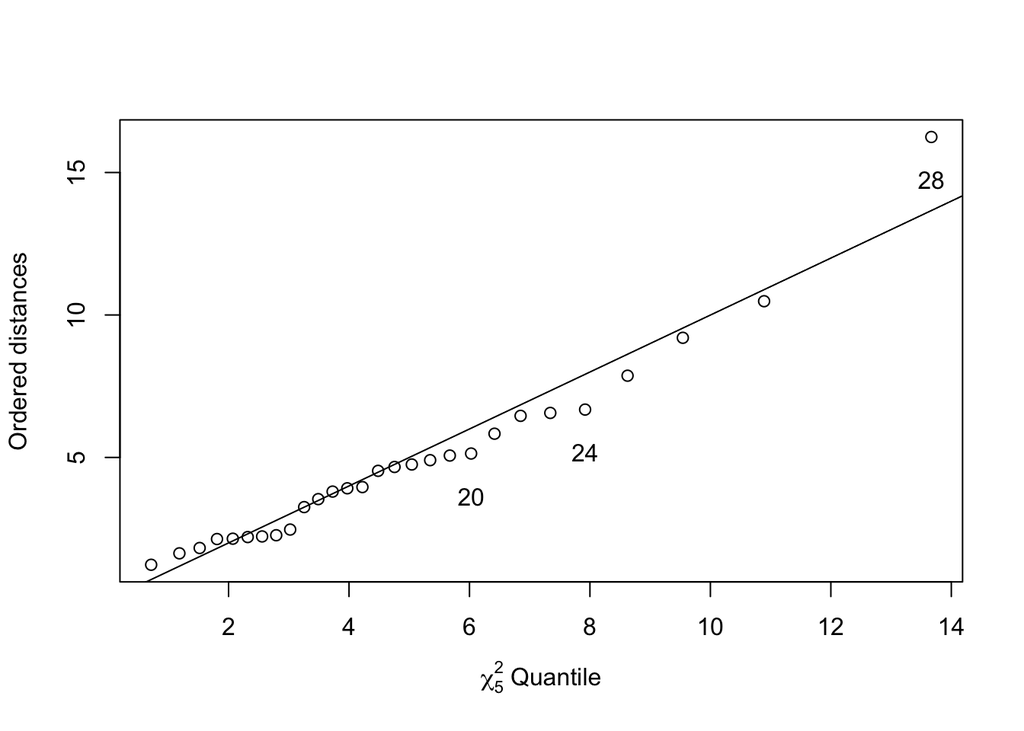

```r
plot(qc <- qchisq((1:nrow(ns_sp) - 1/2) / nrow(ns_sp), df = 5), sd <- sort(d_ns),xlab = expression(paste(chi[5]^2, " Quantile")),ylab = "Ordered distances")
oups <- which(rank(abs(qc - sd), ties = "random") > nrow(ns_sp) - 3)
text(qc[oups], sd[oups] - 1.5,oups)
abline(a = 0, b = 1)
```

- This distribution is also not normally distributed.
- There are also 3 outliers in the data which are observation 20, 24, and 28 in the ns_sp data frame.

## Survived Plots

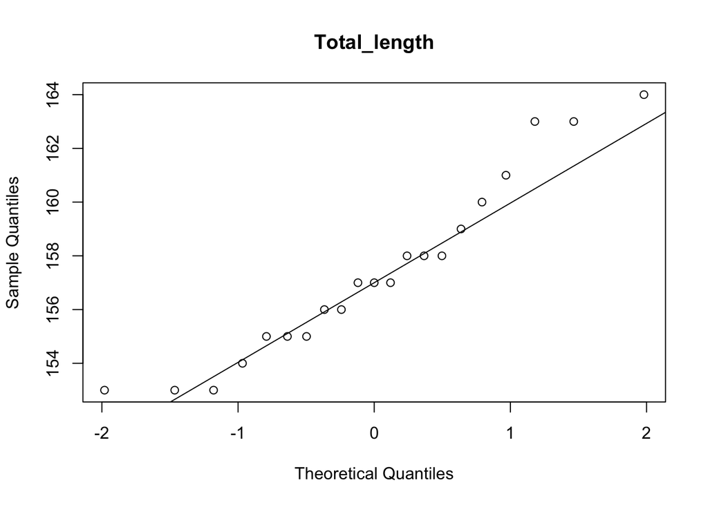

```r
s_sp <- as.data.frame(s_sp)
cm_s_sp <- colMeans(s_sp)
cov_s_sp <- cov(s_sp)
d_s <- apply(s_sp, MARGIN = 1, function(s_sp)t(s_sp - cm_s_sp) %*% solve(cov_s_sp) %*% (s_sp - cm_s_sp))
qqnorm(s_sp[,"Total_length"], main = "Total_length"); qqline(s_sp[,"Total_length"])
```

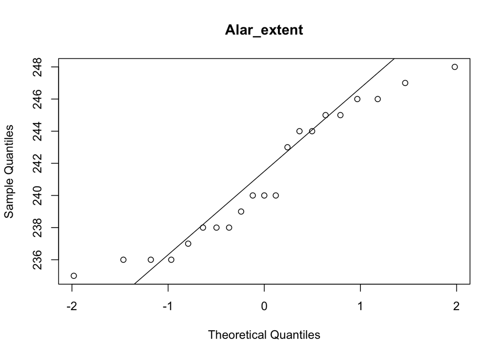

```r
qqnorm(s_sp[,"Alar_extent"], main = "Alar_extent"); qqline(s_sp[,"Alar_extent"])
```

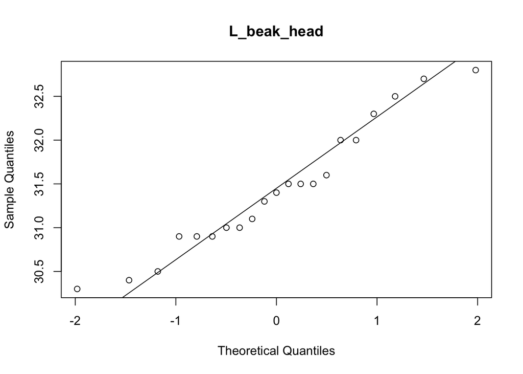

```r
qqnorm(s_sp[,"L_beak_head"], main = "L_beak_head"); qqline(s_sp[,"L_beak_head"])
```

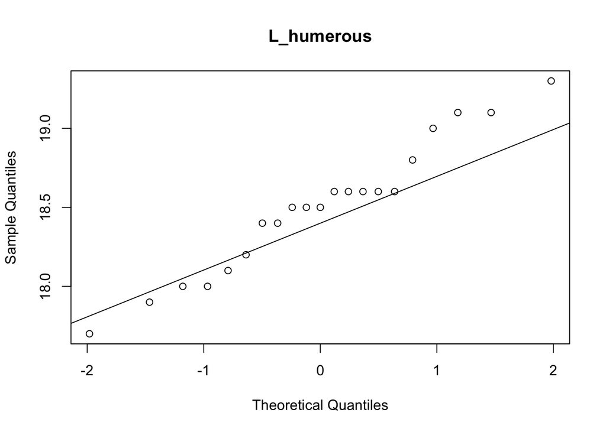

```r
qqnorm(s_sp[,"L_humerous"], main = "L_humerous"); qqline(s_sp[,"L_humerous"])
```

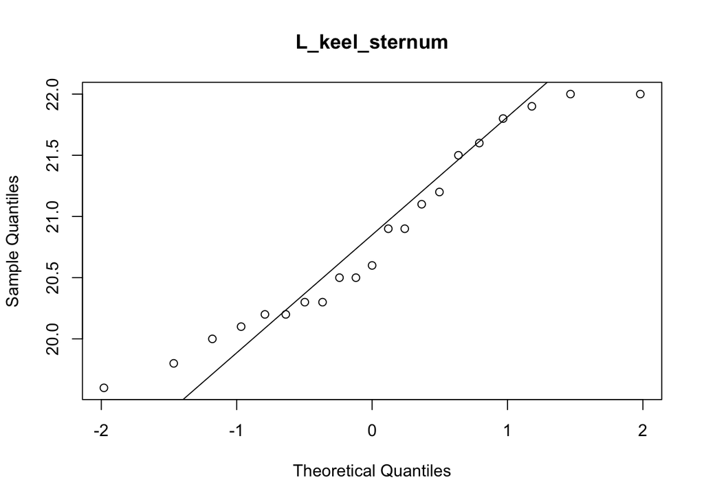

```r
qqnorm(s_sp[,"L_keel_sternum"], main = "L_keel_sternum"); qqline(s_sp[,"L_keel_sternum"])
```

- For Survived sparrows, none of the 5 columns appear to be normally distributed.

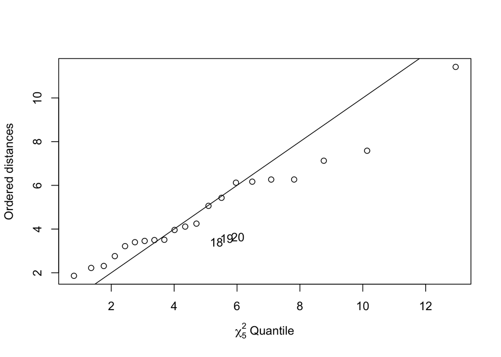

```r
plot(qc1 <- qchisq((1:nrow(s_sp) - 1/2) / nrow(s_sp), df = 5), sd1 <- sort(d_s),xlab = expression(paste(chi[5]^2, " Quantile")),ylab = "Ordered distances")
oups <- which(rank(abs(qc1 - sd1), ties = "random") > nrow(s_sp) - 3)
text(qc[oups], sd[oups] - 1.5,oups)
abline(a = 0, b = 1)
```